# Homework 4

Diana Rueda

10/31/2021

# Question 1

```r
# Confirm my result from hand calculations
polyroot(c(1,-1.6,0.64))
```

```
## [1] 1.25-0i 1.25+0i
```

#### (b) plot the acf of the process. (Use the function ARMAacf() to compute the exact acf ordinates.)

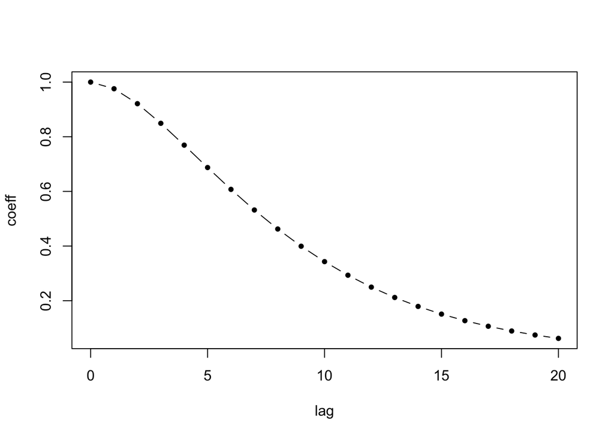

```r
coeff = ARMAacf(ar = c(1.6, -0.64), lag.max = 20)
lags = 0:20
plot(coeff ~ lags, type='b', pch=20, xlab='lag')
```

#### (c) use the R function ARMAtoMA() to determine the first 20 𝜓-weights in the causal representation 𝑋𝑡=∑∞𝑗=0𝜓𝑗𝑊𝑡−𝑗. Use those 𝜓 weights to approximate the corresponding ACF values 𝜌(ℎ) , ℎ=0,1,2,3

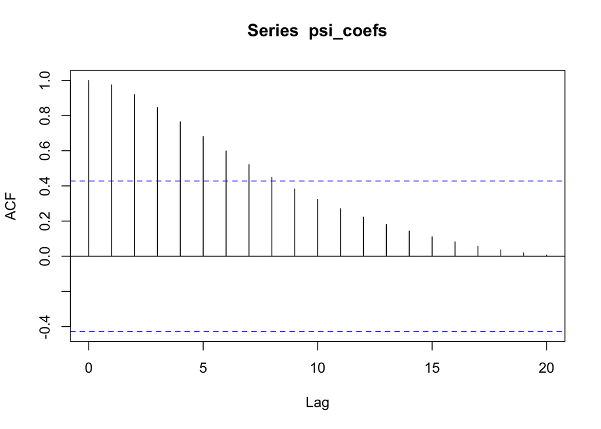

```r
psi_coefs <- c(1, ARMAtoMA(ar=c(1.6,-0.64), lag.max=20))

gamma_0 = sum(psi_coefs^2)

gamma_1 = 0
for (j in 1:20) {
  i = j+1
  num = psi_coefs[j] * psi_coefs[i]
  gamma_1 = gamma_1 + num
}

gamma_2 = 0
for (j in 1:19) {
  i = j+2
  num = psi_coefs[j] * psi_coefs[i]
  gamma_2 = gamma_2 + num
}

gamma_3 = 0
for (j in 1:18) {
  i = j+2
  num = psi_coefs[j] * psi_coefs[i]
  gamma_3 = gamma_3 + num
}

rhos = c(1, gamma_1 / gamma_0, gamma_2 / gamma_0, gamma_3 / gamma_0)


acf(psi_coefs, lag.max = 20, demean = F )
```

The first 20 psi weight are as follows:

```r
psi_coefs
```

```
##  [1] 1.0000000 1.6000000 1.9200000 2.0480000 2.0480000 1.9660800 1.8350080
##  [8] 1.6777216 1.5099494 1.3421773 1.1811160 1.0307922 0.8933532 0.7696581
## [15] 0.6597070 0.5629500 0.4785075 0.4053240 0.3422736 0.2882304 0.2421135
```

The value for gamma1, gamma1, gamma2 and gamma3 are as follows:

```r
values = c(gamma_0,gamma_1,gamma_2,gamma_3)
data.frame(values, row.names = c('gamma0','gamma1','gamma2','gamma3'))
```

```
##          values
## gamma0 35.01612
## gamma1 34.13211
## gamma2 32.18009
## gamma3 32.09722
```

# Question 3

#### Compute the 𝛾(0),𝛾(1),𝛾(2) for the following ARMA process.

The psi weight used to calculate gamma0, gamma1 and gamma2 are:

```r
psi_coef = c(1, ARMAtoMA( ar = c(0,0.8), ma = c(0.6), lag.max= 20 ) )
psi_coef
```

```
##  [1] 1.00000000 0.60000000 0.80000000 0.48000000 0.64000000 0.38400000
##  [7] 0.51200000 0.30720000 0.40960000 0.24576000 0.32768000 0.19660800
## [13] 0.26214400 0.15728640 0.20971520 0.12582912 0.16777216 0.10066330
## [19] 0.13421773 0.08053064 0.10737418
```

```r
gamma_0 = sum(psi_coef^2)

gamma_1 = 0
for (j in 1:20) {
  i = j+1
  num = psi_coef[j] * psi_coef[i]
  gamma_1 = gamma_1 + num
}

gamma_2 = 0
for (j in 1:19) {
  i = j+2
  num = psi_coef[j] * psi_coef[i]
  gamma_2 = gamma_2 + num
}
```

The value for gamma1, gamma1 and gamma2 are as follows:

```r
values = c(gamma_0,gamma_1,gamma_2)
data.frame(values, row.names = c('gamma0','gamma1','gamma2'))
```

```
##          values
## gamma0 3.745752
## gamma1 2.965412
## gamma2 2.982190
```

# Question 6

#### File HW4_Q6_data.csv (available in the folder “Datasets”) contains a time series observations for time t = 1,2,…,900

#### (a) plot the time series. Is there an apparent departure from stationarity?

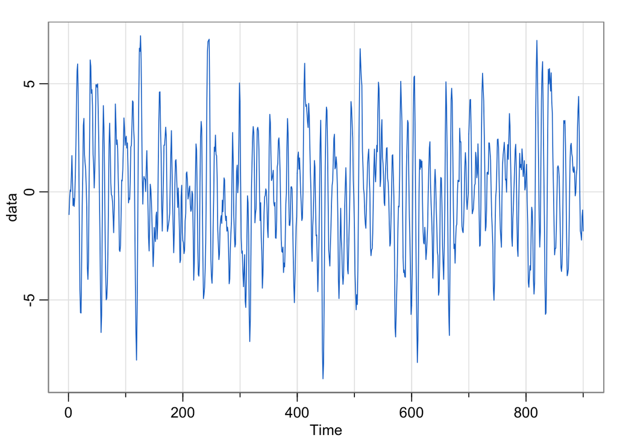

```r
library('astsa')
data = read.csv('HW4_Q6_data.csv')
data = ts(data)
tsplot(data, col = 4)
```

There is not an apparent departure from stationarity.

#### (b) Determine an appropriate ARMA model for the data. Explain how you determined the order of the model.

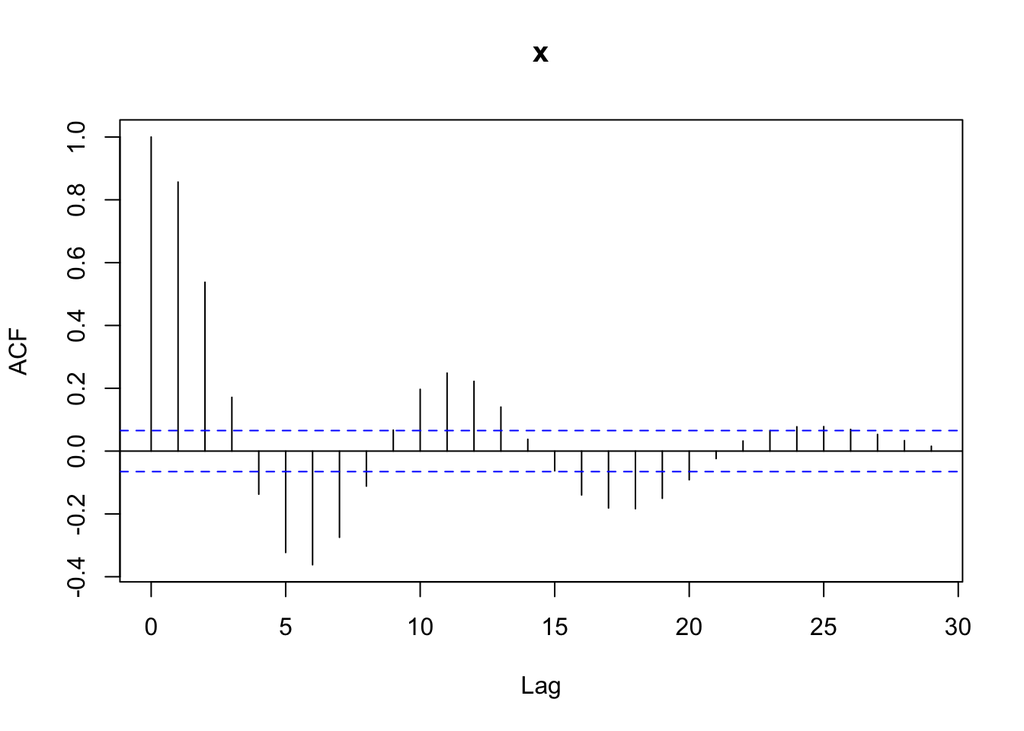

```r
acf(data)
```

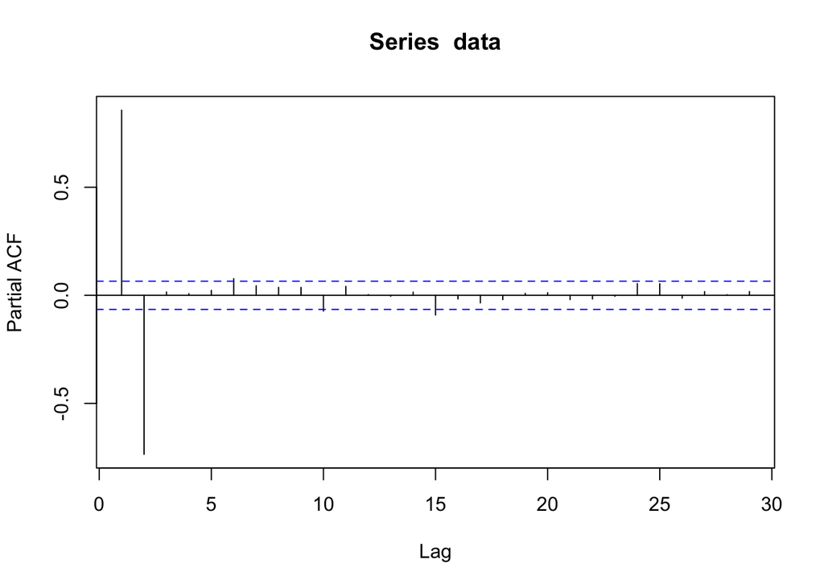

```r
acf(data, type = 'partial')
```

The appropiate model for this process is an AR(2) and we obtained this by observing the ACF and PACF plots. The ACF tails off while the PACF cuts off at p = 2.

#### (c) Based on your answer in part (b), estimate the parameters of the ARMA model and construct a 95% confidence interval for the estimated coefficients.

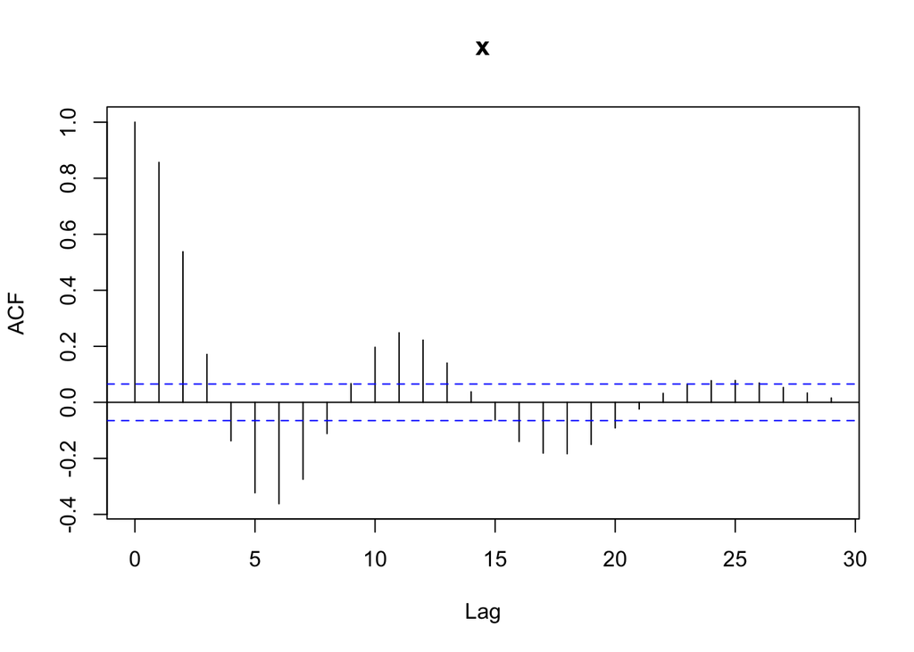

```r
acf_data = acf(data)
```

```r
rho_1 = acf_data[[1]][2]
rho_2 = acf_data[[1]][3]
gamma_0 = sum((data - mean(data))^2) / 900
R = matrix(c(1, rho_1, rho_1, 1), nrow = 2)
phi_data = solve(R)%*%c(rho_1, rho_2)
sigma_squared = gamma_0 * (1 - t(c(rho_1, rho_2))%*%phi_data)

n = length(data)
s = as.vector(sigma_squared / (n * gamma_0)) * solve(R)
est1_ci = c(phi_data[1] - 1.96 * s[1,1], phi_data[1] + 1.96 * s[1,1])

est2_ci = c(phi_data[2] - 1.96 * s[2,2], phi_data[2] + 1.96 * s[2,2])
```

The estimated parameters are as follows:

```r
phi_data
```

```
##            [,1]
## [1,]  1.4863259
## [2,] -0.7353793
```

… with sigma squared

```r
sigma_squared
```

```
##           [,1]
## [1,] 0.9401966
```

The 95% Confidence Interval for the estimation of the first parameter is:

```r
est1_ci
```

```
## [1] 1.485326 1.487326
```

The 95% Confidence Interval for the estimation of the second parameter is:

```r
est2_ci
```

```
## [1] -0.7363793 -0.7343792
```